# You as a language model?

Go to http://www.menti.com and use the code **`61 48 82`**.

### To run these slides:

```
# opens the runable notebook
$ jupyter notebook tnteval.ipynb

# serves the notebook as HTML slide show
$ jupyter nbconvert tnteval.ipynb --to slides --post serve
```

(Provided you have Python installed. I use Anaconda: https://www.continuum.io/downloads)

# Part-of-speech tagger evaluation

### Preliminaries

We assume the taggers are already trained, and the test sets tagged.

#### Train

```
for lang in cs de en fr hi; do
    ./tnt/tnt-para -o models/${lang} data/${lang}.train
done
```

#### Run

```
for lang in cs de en fr hi; do
    ./tnt/tnt models/${lang} data/${lang}.test > data/${lang}.test.tagged
done
```

We typicall evaluate part-of-speech (POS) taggers for:

1. overall accuracy
2. accuracy on known vs. unknown words with respect to training data
3. precision and recall on different POS tags
4. speed

### Datasets

Here, we work with five languages: Czech, English, French, German, and Hindi.

Each language bundles three files: `LANG.{train|test|test.tagged}`.

They respectively contain the training data, manually annotated test data, and tagged test set data.

### Reading the data

```python
def load_tagged_file(filename):
    """
    Reads the part-of-speech-tagged data in "word[\t]tag[\n]" format
    as a list of sentences, which are in turn lists of <word, tag> pairs.
    """
    unique_words = set()
    sentences = []
    current = []
    with open(filename) as file:
        for line in file:
            line = line. strip()
            if line:
                word, tag = line.split("\t")
                current.append((word, tag))
                unique_words.add(word)
            else:  # empty line is sentence delimiter
                sentences.append(current)
                current = []
    return sentences, unique_words
```

```python
langs = ["cs", "de", "en", "fr", "hi"]
data = {}
for lang in langs:
    training, lexicon = load_tagged_file("data/{}.train".format(lang))
    test, _ = load_tagged_file("data/{}.test".format(lang))
    tagged, _ = load_tagged_file("data/{}.test.tagged".format(lang))
    data[lang] = (lexicon, training, test, tagged)
```

### Some basic stats

```python
print("lang\t#unique\t#train\t#test\t#tagged")

for lang, datasets in data.items():
    unique_train = len(datasets[0])
    words_train = sum([len(sentence) for sentence in datasets[1]])
    words_test = sum([len(sentence) for sentence in datasets[2]])
    words_tagged = sum([len(sentence) for sentence in datasets[3]])
    print("{:2}\t{}\t{}\t{}\t{}".format(lang,
                                        unique_train,
                                        words_train,
                                        words_test,
                                        words_tagged))
```

```
lang	#unique	#train	#test	#tagged
de	49472	274345	12512	12512
hi	16974	281057	35217	35217
fr	42258	366214	36824	36824
en	19672	204605	25148	25148
cs	125358	1175374	159610	159610
```

### Calculating the accuracy

We define POS tagging accuracy as:

$$\mathrm{accuracy}=\frac{\mathrm{number~of~words~with~correct~POS~tag}}{\mathrm{total~number~of~words}}$$

```python
def get_accuracy(s_data, g_data):
    """
    Caluclates POS tagging accuracy with respect to gold data.
    """
    total = 0
    correct = 0
    for s_sent, g_sent in zip(s_data, g_data):
        for (_, s_tag), (_, g_tag) in zip(s_sent, g_sent):
            total += 1
            if s_tag == g_tag:
                correct += 1
    return correct/total
```

First, we get all the accuracies.

```python
accuracies = {lang:get_accuracy(data[lang][2], data[lang][3]) for lang in langs}
```

```python
accuracies
```

```
{'cs': 0.9806089843994737,
 'de': 0.9292679028132992,
 'en': 0.9220613965325274,
 'fr': 0.9623343471648924,
 'hi': 0.9423573842178493}
```

Then, we plot them into a bar chart.

```
env: LC_ALL="en_US.UTF-8"
```

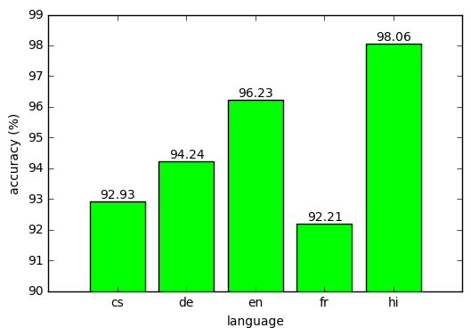

```python
%env LC_ALL="en_US.UTF-8"
%matplotlib inline
import matplotlib.pyplot as plt
import numpy as np

values = np.array(list(accuracies.values()))*100

fig, ax = plt.subplots()
ax.bar(np.arange(len(langs)), values, align="center", color="lime")
plt.xlim(-1,5)
plt.ylim(90,99)
ax.set_xticklabels([""] + langs)
ax.set_xlabel("language")
ax.set_ylabel("accuracy (%)")

for i, v in enumerate(values):
    ax.text(i-0.25, v+0.1, "{:.2f}".format(v))
```

Or, a more honest bar chart...

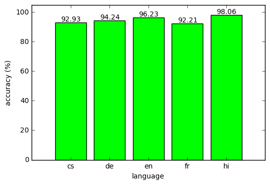

```python
values = np.array(list(accuracies.values()))*100

fig, ax = plt.subplots()
ax.bar(np.arange(len(langs)), values, align="center", color="lime")
plt.xlim(-1,5)
plt.ylim(0,105)
ax.set_xticklabels([""] + langs)
ax.set_xlabel("language")
ax.set_ylabel("accuracy (%)")

for i, v in enumerate(values):
    ax.text(i-0.25, v+1, "{:.2f}".format(v))
```

### Known and unknown words

First, we get the accuracies separately for words that are:

1. seen by the taggers at training time
2. words unique to the test sets

```python
def get_accuracy_known_vs_unknown(s_data, g_data, lexicon):
    """
    Separates the accuracy for known and unknown words.
    Known = exists in the training set.
    """
    correct_known = 0
    correct_unknown = 0
    total_known = 0
    total_unknown = 0
    for s_sent, g_sent in zip(s_data, g_data):
        for (word, s_tag), (_, g_tag) in zip(s_sent, g_sent):
            if word in lexicon:
                total_known += 1
                correct_known += int(s_tag == g_tag)
            else:
                total_unknown += 1
                correct_unknown += int(s_tag == g_tag)
    return correct_known/total_known, correct_unknown/total_unknown
```

```python
accuracies_ku = {lang:get_accuracy_known_vs_unknown(data[lang][2],
                                                    data[lang][3],
                                                    data[lang][0])
                 for lang in langs}
```

```python
accuracies_ku
```

```
{'cs': (0.9863893048271972, 0.9000280819994384),
 'de': (0.9417164245610908, 0.8210689388071263),
 'en': (0.9369849943620435, 0.7574162679425838),
 'fr': (0.9691987573999179, 0.8756476683937824),
 'hi': (0.953026706231454, 0.7053394858272907)}
```

Then, we plot these separately.

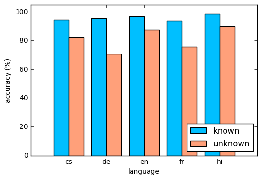

```python
values_known = np.array([k for k, u in list(accuracies_ku.values())])*100
values_unknown = np.array([u for k, u in list(accuracies_ku.values())])*100

fig, ax = plt.subplots()

ax.bar(np.arange(len(langs))-0.2, values_known, width=0.4,
       align="center", color="deepskyblue", label="known")
ax.bar(np.arange(len(langs))+0.2, values_unknown, width=0.4,
       align="center", color="lightsalmon", label="unknown")

plt.xlim(-1,5)
plt.ylim(0,105)
plt.legend(loc=4)
ax.set_xticklabels([""] + langs)
ax.set_xlabel("language")
ax.set_ylabel("accuracy (%)")
```

How many unknown words are there in the test sets?

```python
unknowns = {}
for lang in langs:
    unk = sum([int(word not in data[lang][0])
               for sentence in data[lang][2] for word, tag in sentence])
    total = sum([1 for sentence in data[lang][2]
                 for word, tag in sentence])
    unknowns[lang] = unk/total
```

```python
unknowns
```

```
{'cs': 0.06693189649771318,
 'de': 0.1031809462915601,
 'en': 0.0831080006362335,
 'fr': 0.0733760590918966,
 'hi': 0.043075787261833774}
```

### Precision and recall

How well does a tagger perform with a specific word type? Say, `NOUN`, `VERB`, or `ADJ`?

[figure not shown]

Or, in Python code...

```python
def get_precision_and_recall(s_data, g_data, tag):
    """
    Precision and recall for a single POS tag.
    Expressed in terms of true|false positives|negatives.
    """
    true_positives = 0
    true_negatives = 0
    false_positives = 0
    false_negatives = 0
    correct = 0
    for s_sent, g_sent in zip(s_data, g_data):
        for (_, s_tag), (_, g_tag) in zip(s_sent, g_sent):
            if tag == s_tag:  # system predicts tag...
                if s_tag == g_tag:  # ...and the prediction is correct
                    true_positives += 1
                else:  # ...and the prediction is incorrect
                    false_positives += 1
            else:  # system didn't predict tag...
                if tag == g_tag:  # ...and it should have
                    false_negatives += 1
                else:  # ...and it shouldn't have
                    true_negatives += 1
    precision = true_positives/(true_positives + false_positives)
    recall = true_positives/(true_positives + false_negatives)
    return precision, recall
```

```python
tags = ["ADJ", "NOUN", "PROPN", "VERB"]

from collections import defaultdict
precisions = defaultdict(lambda: defaultdict())
recalls = defaultdict(lambda: defaultdict())

for lang in langs:
    for tag in tags:
        precision, recall = get_precision_and_recall(data[lang][3],
                                                     data[lang][2], tag)
        precisions[lang][tag] = round(precision * 100, 2)
        recalls[lang][tag] = round(recall * 100, 2)
```

And now for some table views...

```python
import pandas as pd
```

```python
pd.DataFrame.from_dict(precisions)
```

|  | cs | de | en | fr | hi |
| --- | --- | --- | --- | --- | --- |
| ADJ | 98.53 | 78.00 | 88.40 | 90.70 | 89.38 |
| NOUN | 98.87 | 95.54 | 90.29 | 95.58 | 92.04 |
| PROPN | 92.36 | 75.54 | 86.04 | 91.72 | 88.10 |
| VERB | 98.74 | 92.46 | 91.67 | 95.21 | 97.10 |

```python
pd.DataFrame.from_dict(recalls)
```

|  | cs | de | en | fr | hi |
| --- | --- | --- | --- | --- | --- |
| ADJ | 98.18 | 89.20 | 89.44 | 91.26 | 93.05 |
| NOUN | 97.91 | 93.09 | 90.87 | 95.19 | 92.76 |
| PROPN | 96.10 | 86.92 | 84.66 | 91.65 | 85.41 |
| VERB | 95.56 | 92.68 | 88.39 | 92.82 | 93.16 |

# Your assignment

[figure not shown]

### Learning curves

1. For each language, train TnT on $n \in \{100, 200, ...\}$ sentences from the training data.
2. Let the maximum $n$ be some common cutoff value across the datasets.
3. Evaluate each of these models on test data.
4. Plot the overall scores. Keep in mind: x-axis = number of words, y-axis = accuracy.
5. Also plot separately for known and unknown words.
6. Write a short abstract summarizing the results of your analysis.